# 2026年4月27日 研究日志

今日主题：整理目前收集到的样本，绘制样本统计表。本周的主要内容就是这个，目前暂未成型，本周五再进行展示吧。今天来总结一下Jupyter的magic吧！

先和不熟悉的朋友讲一声，Jupyter 的 Magic 指令（Magics）是 IPython 提供的“增强语法”，用于执行系统命令、计时、调试、运行脚本、管理环境等。  
它们不是 Python 语法，而是 Notebook 环境的“扩展能力”。所以它们是只有jupyter notebook和相当于进化版的jupyter lab环境中可以使用的魔法哦！

Magic 分两类：

- **行魔法（Line Magics）**：以 `%` 开头，只作用于当前行
- **单元魔法（Cell Magics）**：以 `%%` 开头，作用于整个 cell

# 常用 Magic 指令与示例

## 1. `%time` — 计时单行代码

用于测量**一行代码**的执行时间。

## 2. `%%time` — 计时整个 cell

用于测量**整个 cell**的执行时间。

```python
%time sum([i*i for i in range(10_0000)])
```

```
CPU times: total: 15.6 ms
Wall time: 7.55 ms
```

```
333328333350000
```

```python
%%time
total = 0
for i in range(10_0000):
    total += i*i
total
```

```
CPU times: total: 15.6 ms
Wall time: 12.3 ms
```

```
333328333350000
```

## 3. `%timeit` — 多次运行取平均

适合测量**短代码**的平均性能。

## 4. `%%timeit` — 多次运行整个 cell

对整个 cell 做重复计时。

```python
%timeit [i*i for i in range(1000)]
```

```
36.1 μs ± 4.73 μs per loop (mean ± std. dev. of 7 runs, 10,000 loops each)
```

```python
%%timeit
x = []
for i in range(1000):
    x.append(i*i)
```

```
36.8 μs ± 11.5 μs per loop (mean ± std. dev. of 7 runs, 10,000 loops each)
```

## 5. `%pwd` — 查看当前工作目录

```python
%pwd
```

```
'C:\\Users\\Admin\\TechBlog'
```

## 6. `%cd` — 切换目录

```python
%cd ./data
```

```
C:\Users\Admin\TechBlog\data
```

## 7. `%ls` — 列出当前目录文件

```python
%ls
```

```
 Volume in drive C has no label.
 Volume Serial Number is 12B8-C7B5

 Directory of C:\Users\Admin\TechBlog\data

27/04/2026  17:08    <DIR>          .
27/04/2026  17:08    <DIR>          ..
               0 File(s)              0 bytes
               2 Dir(s)  518,734,532,608 bytes free
```

## 8. `!` — 执行系统命令

在 Notebook 中运行 shell 命令。 *（其实`!`不是 Magic，但也是IPython的机制，和magic一样用，就放在这里了）*

```python
!pip list
```

[output not shown]

[output cut: 379 more lines]

[output not shown]

## 9. `%%writefile` — 将 cell 内容写入文件

```python
%%writefile hello.py
print("Hello, file!")
```

```
Writing hello.py
```

## 10. `%run` — 运行 Python 脚本

```python
%run hello.py
```

```
Hello, file!
```

## 11. `%%cmd` — 在 cell 中书写并运行 cmd 脚本

怎么？我用Windows作为我的主要编程环境不行吗？需要用到Linux系统的场合我都是靠WSL解决的（在Linux中这个命令是`%%bash`，我用Windows所以是这个）

```python
%%cmd
echo Hello from Windows CMD
dir
```

```
Microsoft Windows [Version 10.0.26200.8246]
(c) Microsoft Corporation. All rights reserved.

C:\Users\Admin\TechBlog\data>echo Hello from Windows CMD
Hello from Windows CMD

C:\Users\Admin\TechBlog\data>dir
 Volume in drive C has no label.
 Volume Serial Number is 12B8-C7B5

 Directory of C:\Users\Admin\TechBlog\data

27/04/2026  17:21    <DIR>          .
27/04/2026  17:25    <DIR>          ..
27/04/2026  17:21    <DIR>          .ipynb_checkpoints
27/04/2026  17:16                23 hello.py
               1 File(s)             23 bytes
               3 Dir(s)  518,740,402,176 bytes free

C:\Users\Admin\TechBlog\data>
```

## 12. `%matplotlib inline` — 在 Notebook 内显示图像

这个是Python kernel 专用的，R kernel之类的没法用。*（不过一般情况下，除了我这个用jupyter lab写博客的，也没什么人会用R kernel的notebook了吧）*

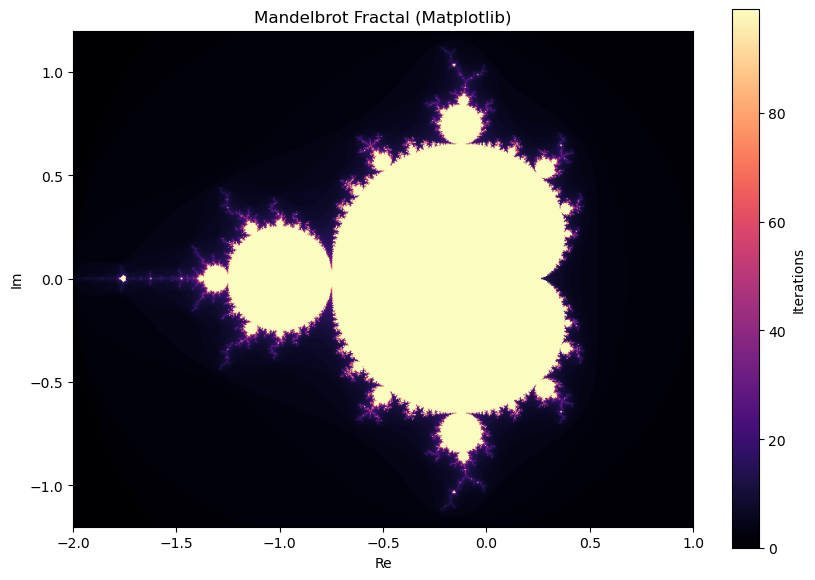

```python
%matplotlib inline
import numpy as np
import matplotlib.pyplot as plt

# 图像大小
width, height = 800, 600

# 生成复平面网格
x = np.linspace(-2.0, 1.0, width)
y = np.linspace(-1.2, 1.2, height)
X, Y = np.meshgrid(x, y)
C = X + 1j * Y

# 初始化
Z = np.zeros_like(C)
iterations = np.zeros(C.shape, dtype=int)

max_iter = 100

# 迭代计算 Mandelbrot 集合
for i in range(max_iter):
    mask = np.abs(Z) <= 2
    Z[mask] = Z[mask] * Z[mask] + C[mask]
    iterations[mask] = i

# 绘图
plt.figure(figsize=(10, 7))
plt.imshow(iterations, cmap="magma", extent=[-2, 1, -1.2, 1.2])
plt.colorbar(label="Iterations")
plt.title("Mandelbrot Fractal (Matplotlib)")
plt.xlabel("Re")
plt.ylabel("Im")
plt.show()
```

# 📊 Magic 常用指令功能汇总表

（执行系统命令的指令也算进来了，反正都一样用，都一样都一样）

| 指令 | 类型 | 功能 |
| --- | --- | --- |
| `%time` | 行魔法 | 测量单行代码执行时间 |
| `%%time` | 单元魔法 | 测量整个 cell 执行时间 |
| `%timeit` | 行魔法 | 多次运行取平均时间 |
| `%%timeit` | 单元魔法 | 多次运行整个 cell |
| `%pwd` | 行魔法 | 显示当前工作目录 |
| `%ls` | 行魔法 | 列出目录内容 |
| `%cd` | 行魔法 | 切换目录 |
| `!command` | Shell | 执行系统命令 |
| `%run` | 行魔法 | 运行 Python 脚本 |
| `%%bash` | 单元魔法 | 在 cell 中运行 bash |
| `%matplotlib inline` | 行魔法 | Notebook 内显示图像 |
| `%%writefile` | 单元魔法 | 将 cell 内容写入文件 |

*要是不嫌麻烦，用下面这个指令可以查看所有magic指令*

```python
%lsmagic
```

```
Available line magics:
%alias  %alias_magic  %autoawait  %autocall  %automagic  %autosave  %bookmark  %cd  %clear  %cls  %code_wrap  %colors  %conda  %config  %connect_info  %copy  %ddir  %debug  %dhist  %dirs  %doctest_mode  %echo  %ed  %edit  %env  %gui  %hist  %history  %killbgscripts  %ldir  %less  %load  %load_ext  %…

Available cell magics:
%%!  %%HTML  %%SVG  %%bash  %%capture  %%cmd  %%code_wrap  %%debug  %%file  %%html  %%javascript  %%js  %%latex  %%markdown  %%perl  %%prun  %%pypy  %%python  %%python2  %%python3  %%ruby  %%script  %%sh  %%svg  %%sx  %%system  %%time  %%timeit  %%writefile

Automagic is ON, % prefix IS NOT needed for line magics.
```